# Project: Trends in Gun Background Checks in the United States : 1998 - 2017

- Introduction
- Data Wrangling
- Exploratory Data Analysis
- Conclusions

## Introduction

This report will analyze FBI gun data from the National Instant Criminal Background Check System (NICS). This system is used by gun sellers (for example, gun stores, pawn shops, etc.) to determine if the buyer is legally permitted to make the purchase. More information about the program can be found on the [FBI's NICS page](https://www.fbi.gov/services/cjis/nics/about-nics).

Specifically, the [NICS dataset](https://d17h27t6h515a5.cloudfront.net/topher/2017/November/5a0a4db8_gun-data/gun-data.xlsx) used in this analysis is an .xlsx file that contains the number of background checks per month by state and by type of check (for example, permit, handgun, long gun, etc.) from November 1998 to September 2017. The source of the data is from [Buzz Feed News](https://github.com/BuzzFeedNews/nics-firearm-background-checks/blob/master/README.md), who aggregated data obtained from the FBI. They mention that the original data from the FBI included the following very important caveat regarding what the data can tell us:

> These statistics represent the number of firearm background checks initiated through the NICS. They do not represent the number of firearms sold. Based on varying state laws and purchase scenarios, a one-to-one correlation cannot be made between a firearm background check and a firearm sale.

For the purpose of this report, I think it is safe to assume that the background checks can be used as an indicator of interest in purchasing a firearm.

This data is supplemented with [U.S. Census data](https://d17h27t6h515a5.cloudfront.net/topher/2017/November/5a0a554c_u.s.-census-data/u.s.-census-data.csv) provided by the Udacity Data Analyst Nanodegree program. The linked .csv file contains statistics per state regarding population, education levels, per capita income, poverty levels, etc.

In this analysis we will investigate the following questions.

(1) *Is interest in gun purchases cyclical? For example, can we determine if there is more interest after specific events, such as presidential elections? Are there any patterns that we can see over time?*

(2) *People from which states show the most intetest in obtaining a firearm? (i.e. which states have the most background checks per capita?)*

(3) *Which demographic characteristics are most correlated with an interest in purchasing a firearm? Specifically, are education levels, poverty rates, and population density (i.e. more or less urban or rural) correlated with the number of background checks?*

```python
# Set up import statements for all of the packages that will be used
import numpy as np
import pandas as pd
import matplotlib.pyplot as plt
import seaborn as sns
# Plot visualizations in this notebook
%matplotlib inline
```

## Data Wrangling

### General Properties

Let's look at each of our datasets more closely. First, will will inspect our data to ensure that the correct data types are being used. We will also look for missing or errant data. Then will will fix any issues.

### NICS Dataset Inspection

Let's load and look at the NICS dataset first, in particular let's print the first few rows.

```python
# Load the spreadsheet that contains the NICS background check data.
df_guns = pd.read_excel('gun_data.xlsx')
df_guns.head()
```

|  | month | state | permit | permit_recheck | handgun | long_gun | other | multiple | admin | prepawn_handgun | ... | returned_other | rentals_handgun | rentals_long_gun | private_sale_handgun | private_sale_long_gun | private_sale_other | return_to_seller_handgun | return_to_seller_long_gun | return_to_seller_other | totals |
| --- | --- | --- | --- | --- | --- | --- | --- | --- | --- | --- | --- | --- | --- | --- | --- | --- | --- | --- | --- | --- | --- |
| 0 | 2017-09 | Alabama | 16717.0 | 0.0 | 5734.0 | 6320.0 | 221.0 | 317 | 0.0 | 15.0 | ... | 0.0 | 0.0 | 0.0 | 9.0 | 16.0 | 3.0 | 0.0 | 0.0 | 3.0 | 32019 |
| 1 | 2017-09 | Alaska | 209.0 | 2.0 | 2320.0 | 2930.0 | 219.0 | 160 | 0.0 | 5.0 | ... | 0.0 | 0.0 | 0.0 | 17.0 | 24.0 | 1.0 | 0.0 | 0.0 | 0.0 | 6303 |
| 2 | 2017-09 | Arizona | 5069.0 | 382.0 | 11063.0 | 7946.0 | 920.0 | 631 | 0.0 | 13.0 | ... | 0.0 | 0.0 | 0.0 | 38.0 | 12.0 | 2.0 | 0.0 | 0.0 | 0.0 | 28394 |
| 3 | 2017-09 | Arkansas | 2935.0 | 632.0 | 4347.0 | 6063.0 | 165.0 | 366 | 51.0 | 12.0 | ... | 0.0 | 0.0 | 0.0 | 13.0 | 23.0 | 0.0 | 0.0 | 2.0 | 1.0 | 17747 |
| 4 | 2017-09 | California | 57839.0 | 0.0 | 37165.0 | 24581.0 | 2984.0 | 0 | 0.0 | 0.0 | ... | 0.0 | 0.0 | 0.0 | 0.0 | 0.0 | 0.0 | 0.0 | 0.0 | 0.0 | 123506 |

5 rows × 27 columns

We can make a few observations right away. First, our dataset appears to be listed in reverse chronological order, as the first few rows start in 2017. Also, there are too many columns to fit on the screen. Let's find out exactly how many rows and columns there are.

```python
df_guns.shape
```

```
(12485, 27)
```

We have 12485 rows and 27 columns. Let's now look at the headings of our columns and their respective data types.

```python
df_guns.info()
```

```
<class 'pandas.core.frame.DataFrame'>
RangeIndex: 12485 entries, 0 to 12484
Data columns (total 27 columns):
 #   Column                     Non-Null Count  Dtype
---  ------                     --------------  -----
 0   month                      12485 non-null  object
 1   state                      12485 non-null  object
 2   permit                     12461 non-null  float64
 3   permit_recheck             1100 non-null   float64
 4   handgun                    12465 non-null  float64
 5   long_gun                   12466 non-null  float64
 6   other                      5500 non-null   float64
 7   multiple                   12485 non-null  int64
 8   admin                      12462 non-null  float64
 9   prepawn_handgun            10542 non-null  float64
```

[output cut: 19 more lines]

Most of the column names refer to a very specific type of check, for example handgun rental, pawn redemption for a long gun, etc. More detail about what these columns specifically refer to can be found at on the first page of the FBI's [most recent set of data](https://www.fbi.gov/file-repository/nics_firearm_checks_-_month_year_by_state_type.pdf/view). (Note we are actually using an older dataset, however the column names still correspond to our data.) Given the nature of our questions, we won't need all of this detail, so we can probably drop several of these later. Also, all of the column names are lowercase and none have spaces, so we don't need to modify them.

We'll need to investigate the nulls further, but first let's check to see if any of the rows are duplicates.

```python
sum(df_guns.duplicated())
```

```
0
```

```python
df_guns[df_guns.month > '2016-07'].info()
```

```
<class 'pandas.core.frame.DataFrame'>
Int64Index: 770 entries, 0 to 769
Data columns (total 27 columns):
 #   Column                     Non-Null Count  Dtype
---  ------                     --------------  -----
 0   month                      770 non-null    object
 1   state                      770 non-null    object
 2   permit                     770 non-null    float64
 3   permit_recheck             770 non-null    float64
 4   handgun                    770 non-null    float64
 5   long_gun                   770 non-null    float64
 6   other                      770 non-null    float64
 7   multiple                   770 non-null    int64
 8   admin                      770 non-null    float64
 9   prepawn_handgun            770 non-null    float64
```

[output cut: 19 more lines]

We can see that there are no null fields from August 2016 onward. Let's verify that we picked the correct cutoff, by verifying that the July 2016 does contain nulls.

```python
df_guns[df_guns.month == '2016-07'].info()
```

```
<class 'pandas.core.frame.DataFrame'>
Int64Index: 55 entries, 770 to 824
Data columns (total 27 columns):
 #   Column                     Non-Null Count  Dtype
---  ------                     --------------  -----
 0   month                      55 non-null     object
 1   state                      55 non-null     object
 2   permit                     55 non-null     float64
 3   permit_recheck             55 non-null     float64
 4   handgun                    55 non-null     float64
 5   long_gun                   55 non-null     float64
 6   other                      55 non-null     float64
 7   multiple                   55 non-null     int64
 8   admin                      55 non-null     float64
 9   prepawn_handgun            55 non-null     float64
```

[output cut: 19 more lines]

So, how do we handle these nulls? There are a few options: For example, we could fill them with zeros or we could fill them with the mean value for that particular column. Additionally, we could drop the rows or the columns containing nulls.

First, given that there are only 770 rows that don't contain nulls (out of dataset containing 12485 rows), dropping rows with nulls doesn't sound like the best option. We could, however, consider dropping some of the columns, especially if they don't pertain to any of the questions that we will be analyzing.

In order to determine the best course of action, let's see how the 'totals' column is being tracked. This column represents the total of all backgound checks in a given months. Is it a sum of all of the columns from 'permit' to 'return_to_seller_other', meaning that the categories represented by the columns are mutually exclusive? Or, is it possible that a background check can be counted as both 'permit' and 'handgun', meaning that the categories aren't mutually exclusive?

```python
# Sum the categories by row (from "permit" to "return_to_seller_other")
sum_of_cats_by_row = df_guns.loc[:,"permit":"return_to_seller_other"].sum(axis=1)
# See if there are any rows were the sum of all of the categories is not equal to the value in "totals"
df_guns[df_guns.totals != sum_of_cats_by_row]
```

|  | month | state | permit | permit_recheck | handgun | long_gun | other | multiple | admin | prepawn_handgun | ... | returned_other | rentals_handgun | rentals_long_gun | private_sale_handgun | private_sale_long_gun | private_sale_other | return_to_seller_handgun | return_to_seller_long_gun | return_to_seller_other | totals |
| --- | --- | --- | --- | --- | --- | --- | --- | --- | --- | --- | --- | --- | --- | --- | --- | --- | --- | --- | --- | --- | --- |

0 rows × 27 columns

As we can see from the above, the sum of each of the categories is equal to the value in the totals column (otherwise the second statement would have returned values), therefore the categories are mutally exclusive and we can fill our nulls with zeros. This is a better solution than filling them with the average value of the column, as we would lose the property of mutually exclusivity. However, we need to keep in mind that just because we have filled in zeros in a particular column that doesn't mean that it accurately reflects the absense of that type of transaction. For example, a background check classified as handgun could have possibly been classified in another category, such as pre-pawn handgun, at a later date when that category was added.

Additionally, we should note that zeros for a given category could indicate that a state does not require background checks for that type of transaction, not that one didn't occur for that given month. For example, not every state requires background checks for private sales. This should be kept in mind when making comparisons between states. Please consult the FBI NICS link above for more information.

Next, we will address the issue of potentially errant data. One big source of errant data is when data does not have the correct data type, such when numeric values are being stored as text. We don't have that issue in this dataset. However, we should check that our columns that are of floating point type don't have any fractional values, as the number of background checks should be whole numbers. We can do a quick test this using modular arithmetic on each of the floating point columns.

```python
# Search each of the float columns which are located within positions 2 through 25 of the list of columns
# source: https://stackoverflow.com/questions/49249860/how-to-check-if-float-pandas-column-contains-only-integer-numbers
(df_guns.loc[:,"permit":"return_to_seller_other"].fillna(-9999) % 1  == 0).all()
```

```
permit                       True
permit_recheck               True
handgun                      True
long_gun                     True
other                        True
multiple                     True
admin                        True
prepawn_handgun              True
prepawn_long_gun             True
prepawn_other                True
redemption_handgun           True
redemption_long_gun          True
redemption_other             True
returned_handgun             True
returned_long_gun            True
returned_other               True
rentals_handgun              True
rentals_long_gun             True
private_sale_handgun         True
private_sale_long_gun        True
private_sale_other           True
return_to_seller_handgun     True
return_to_seller_long_gun    True
return_to_seller_other       True
dtype: bool
```

As we can see, all of the values in each floating point type column is an integer, as evidenced by the true values above. A quick scroll through the original spreadsheet does not indicate any other errant values either. One last issue that we might want to investigate is whether there is data for U.S. terrories, as these jurisdictions must also use NICS. Having taken a cursory look at the U.S. Census data, we know that it just contains data for the 50 states. If the NICS data contains information for U.S. territories, we should consider removing it as we wouldn't be able to use it with the census data.

```python
df_guns.state.unique()
```

```
array(['Alabama', 'Alaska', 'Arizona', 'Arkansas', 'California',
       'Colorado', 'Connecticut', 'Delaware', 'District of Columbia',
       'Florida', 'Georgia', 'Guam', 'Hawaii', 'Idaho', 'Illinois',
       'Indiana', 'Iowa', 'Kansas', 'Kentucky', 'Louisiana', 'Maine',
       'Mariana Islands', 'Maryland', 'Massachusetts', 'Michigan',
       'Minnesota', 'Mississippi', 'Missouri', 'Montana', 'Nebraska',
       'Nevada', 'New Hampshire', 'New Jersey', 'New Mexico', 'New York',
       'North Carolina', 'North Dakota', 'Ohio', 'Oklahoma', 'Oregon',
       'Pennsylvania', 'Puerto Rico', 'Rhode Island', 'South Carolina',
       'South Dakota', 'Tennessee', 'Texas', 'Utah', 'Vermont',
       'Virgin Islands', 'Virginia', 'Washington', 'West Virginia',
       'Wisconsin', 'Wyoming'], dtype=object)
```

We can see that territories and the District of Columbia are indeed included and should be considered for removal if we want to supplement our data set with the census data.

### NICS Data Cleaning

Our analysis above identified four issues to fix:

(1) Replace our null values with zeros.\ (2) Change floating point columns to integers.\ (3) Remove territories and the District of Columbia.\ (3) Remove columns that won't be used from our dataframe.

First, let's remove the territories and District of Columbia.

```python
# Drop rows containing territories or D.C. in the state column
df_guns.drop(index = df_guns[df_guns['state'].str.contains("Guam|Mariana Islands|Virgin Islands|Puerto Rico|District of Columbia")==True].index,inplace=True)
```

```python
# Verify that the territories have been removed - should return 0 rows
df_guns[df_guns['state'].str.contains("Guam|Mariana Islands|Virgin Islands|Puerto Rico|District of Columbia")==True]
```

|  | month | state | permit | permit_recheck | handgun | long_gun | other | multiple | admin | prepawn_handgun | ... | returned_other | rentals_handgun | rentals_long_gun | private_sale_handgun | private_sale_long_gun | private_sale_other | return_to_seller_handgun | return_to_seller_long_gun | return_to_seller_other | totals |
| --- | --- | --- | --- | --- | --- | --- | --- | --- | --- | --- | --- | --- | --- | --- | --- | --- | --- | --- | --- | --- | --- |

0 rows × 27 columns

Next, let's replace our nulls with zeros.

First, let's get a count of the rows that contain nulls. Since 'rentals_handgun' was one of the last columns to be added, it should have the most nulls and make an accurate count so that we can double check that they've been filled.

```python
sum(df_guns['rentals_handgun'].isnull())
```

```
10450
```

Let's replace the nulls with zeros, then test that there are no more nulls.

```python
# Fill nulls with zeros
df_guns.fillna(0, inplace = True)
# Count the number of nulls remaining in the dataframe
sum(df_guns['rentals_handgun'].isnull())
```

```
0
```

Now, let's change the float data type columns to integer.

```python
# It doesn't matter if we include 'multiple', as it's already an integer
df_guns.loc[:,"permit":"return_to_seller_other"] = df_guns.loc[:,"permit":"return_to_seller_other"].astype(int)
# Double check our work
df_guns.info()
```

```
<class 'pandas.core.frame.DataFrame'>
Int64Index: 11350 entries, 0 to 12484
Data columns (total 27 columns):
 #   Column                     Non-Null Count  Dtype
---  ------                     --------------  -----
 0   month                      11350 non-null  object
 1   state                      11350 non-null  object
 2   permit                     11350 non-null  int64
 3   permit_recheck             11350 non-null  int64
 4   handgun                    11350 non-null  int64
 5   long_gun                   11350 non-null  int64
 6   other                      11350 non-null  int64
 7   multiple                   11350 non-null  int64
 8   admin                      11350 non-null  int64
 9   prepawn_handgun            11350 non-null  int64
```

[output cut: 19 more lines]

At this point our full NICS dataset has been cleaned. Earlier I suggested dropping columns that we won't use in our analysis. Before we proceed, let's save a full version of the dataframe just in case we want to come back to it later and look at the columns we dropped.

```python
df_guns_full = df_guns.copy()
```

Given that our questions don't drill down into some of the more specific types of transactions (pawn, rental, private) and because the month, state, permit, handgun, long_gun, multiple, admin and totals columns are consitently tracked over the entire time, let's keep these and drop the rest.

```python
# Create a list of the columns that we will be dropping
to_drop = list(df_guns.columns[9:26])
to_drop.append('permit_recheck')
to_drop.append('other')
# Verify its contents
to_drop
```

```
['prepawn_handgun',
 'prepawn_long_gun',
 'prepawn_other',
 'redemption_handgun',
 'redemption_long_gun',
 'redemption_other',
 'returned_handgun',
 'returned_long_gun',
 'returned_other',
 'rentals_handgun',
 'rentals_long_gun',
 'private_sale_handgun',
 'private_sale_long_gun',
 'private_sale_other',
 'return_to_seller_handgun',
 'return_to_seller_long_gun',
 'return_to_seller_other',
 'permit_recheck',
 'other']
```

```python
#Drop the columns we don't need
df_guns.drop(to_drop, axis='columns', inplace=True)
```

Let's get a quick count of our rows and columns.

```python
df_guns.shape
```

```
(11350, 8)
```

Finally, let's get a quick look at our stats.

```python
df_guns.describe()
```

|  | permit | handgun | long_gun | multiple | admin | totals |
| --- | --- | --- | --- | --- | --- | --- |
| count | 11350.000000 | 11350.000000 | 11350.000000 | 11350.000000 | 11350.000000 | 11350.000000 |
| mean | 7040.389515 | 6509.303877 | 8575.439648 | 295.059471 | 64.663700 | 23734.978502 |
| std | 24799.120415 | 8829.284061 | 9416.217660 | 816.710594 | 633.459035 | 33437.577310 |
| min | 0.000000 | 0.000000 | 0.000000 | 0.000000 | 0.000000 | 6.000000 |
| 25% | 0.000000 | 1327.250000 | 2778.000000 | 41.000000 | 0.000000 | 6472.000000 |
| 50% | 813.500000 | 3622.500000 | 5893.000000 | 151.000000 | 0.000000 | 14050.000000 |
| 75% | 5136.750000 | 7987.750000 | 11021.500000 | 328.750000 | 0.000000 | 27537.000000 |
| max | 522188.000000 | 107224.000000 | 108058.000000 | 38907.000000 | 28083.000000 | 541978.000000 |

### Census Data Inspection

Next, let's turn our attention to the census data. First, we'll import the file and take an initial look at it.

```python
# Load the spreadsheet that contains the census data file
df_census = pd.read_csv('U.S._Census_Data.csv')
df_census.head()
```

|  | Fact | Fact Note | Alabama | Alaska | Arizona | Arkansas | California | Colorado | Connecticut | Delaware | ... | South Dakota | Tennessee | Texas | Utah | Vermont | Virginia | Washington | West Virginia | Wisconsin | Wyoming |
| --- | --- | --- | --- | --- | --- | --- | --- | --- | --- | --- | --- | --- | --- | --- | --- | --- | --- | --- | --- | --- | --- |
| 0 | Population estimates, July 1, 2016, (V2016) | NaN | 4,863,300 | 741,894 | 6,931,071 | 2,988,248 | 39,250,017 | 5,540,545 | 3,576,452 | 952,065 | ... | 865454 | 6651194 | 27,862,596 | 3,051,217 | 624,594 | 8,411,808 | 7,288,000 | 1,831,102 | 5,778,708 | 585,501 |
| 1 | Population estimates base, April 1, 2010, (V2... | NaN | 4,780,131 | 710,249 | 6,392,301 | 2,916,025 | 37,254,522 | 5,029,324 | 3,574,114 | 897,936 | ... | 814195 | 6346298 | 25,146,100 | 2,763,888 | 625,741 | 8,001,041 | 6,724,545 | 1,853,011 | 5,687,289 | 563,767 |
| 2 | Population, percent change - April 1, 2010 (es... | NaN | 1.70% | 4.50% | 8.40% | 2.50% | 5.40% | 10.20% | 0.10% | 6.00% | ... | 0.063 | 0.048 | 10.80% | 10.40% | -0.20% | 5.10% | 8.40% | -1.20% | 1.60% | 3.90% |
| 3 | Population, Census, April 1, 2010 | NaN | 4,779,736 | 710,231 | 6,392,017 | 2,915,918 | 37,253,956 | 5,029,196 | 3,574,097 | 897,934 | ... | 814180 | 6346105 | 25,145,561 | 2,763,885 | 625,741 | 8,001,024 | 6,724,540 | 1,852,994 | 5,686,986 | 563,626 |
| 4 | Persons under 5 years, percent, July 1, 2016, ... | NaN | 6.00% | 7.30% | 6.30% | 6.40% | 6.30% | 6.10% | 5.20% | 5.80% | ... | 0.071 | 0.061 | 7.20% | 8.30% | 4.90% | 6.10% | 6.20% | 5.50% | 5.80% | 6.50% |

5 rows × 52 columns

It looks like the 'Fact' column indicates what type of census statistic is represented in the row. The 'Fact Note' column contains any futher explanation of the former. The remaining columns list each state. There are spaces in between some of the column names that we may need to address later.

One thing that stands out is that it might be easier to actually invert the table, transforming the type of census information in 'Fact' into columns. Then each row could reference a state. We could shorten each of the current facts into lowercase column names without spaces. We can leave the text fields of the state alone and verify later that we can join them with the states in our background check data.

There also appear to be some errant or inconsistent values. For example, in the 'Population, percent change...' row, most of the values are listed as a percentage, but some states like South Dakota and Tennessee have decimal values. We will need to fix this so that all of our values are converted into decimal values.

Let's look at how many of these 'Facts' we currently have and see if we if we need all of them.

```python
df_census.shape
```

```
(65, 52)
```

There are 65, which is probably too many, given the scope of the questions we're investigating. We'll need to drop a number of them to make our analysis easier.

Next let's confirm there are no duplicates.

```python
sum(df_census.duplicated())
```

```
0
```

Next, let's look at our data types and nulls.

```python
df_census.info()
```

```
<class 'pandas.core.frame.DataFrame'>
RangeIndex: 65 entries, 0 to 64
Data columns (total 52 columns):
 #   Column          Non-Null Count  Dtype
---  ------          --------------  -----
 0   Fact            65 non-null     object
 1   Fact Note       16 non-null     object
 2   Alabama         65 non-null     object
 3   Alaska          65 non-null     object
 4   Arizona         65 non-null     object
 5   Arkansas        65 non-null     object
 6   California      65 non-null     object
 7   Colorado        65 non-null     object
 8   Connecticut     65 non-null     object
 9   Delaware        65 non-null     object
```

[output cut: 44 more lines]

The only column that contains nulls is the fact note column. We won't need this column and it can be dropped.

All of our data types are text. This means we're going to do a fair amount of clean up. Percent signs and commas will need to be removed from these fields before they can be converted to floating point numbers or integers.

### Census Data Cleaning

Our analysis above identified a number issues that will need to be addressed before using the census data:

(1) Invert our dataframe\ (2) Drop unnecessary Facts\ (3) Rename Facts (elimate spaces and use lowercase)\ (4) Convert numbers to float or integer, depending on what they represent, removing any % signs or commas in the process\ (5) Address data inconsistencies. For example, some states have decimal values instead of percentages for certain census 'Facts'

Let's start by dropping the 'Facts' that we don't need. The questions that we are investigating involve population, education level (high school and university graduation rates), per capita income, poverty rate, and population density. These are represented by indexes 0, 34, 35, 48, 49 and 62 respectively. Let's keep these and drop the rest. Let's also drop the 'Fact Note' column.

```python
# Drop unnecessary facts
df_census = df_census.iloc[[0,34,35,48,49,62]]

#drop Fact Note column too
df_census.drop(columns=['Fact Note'], inplace=True)

# Print the resulting dataframe
df_census
```

|  | Fact | Alabama | Alaska | Arizona | Arkansas | California | Colorado | Connecticut | Delaware | Florida | ... | South Dakota | Tennessee | Texas | Utah | Vermont | Virginia | Washington | West Virginia | Wisconsin | Wyoming |
| --- | --- | --- | --- | --- | --- | --- | --- | --- | --- | --- | --- | --- | --- | --- | --- | --- | --- | --- | --- | --- | --- |
| 0 | Population estimates, July 1, 2016, (V2016) | 4,863,300 | 741,894 | 6,931,071 | 2,988,248 | 39,250,017 | 5,540,545 | 3,576,452 | 952,065 | 20,612,439 | ... | 865454 | 6651194 | 27,862,596 | 3,051,217 | 624,594 | 8,411,808 | 7,288,000 | 1,831,102 | 5,778,708 | 585,501 |
| 34 | High school graduate or higher, percent of per... | 84.30% | 92.10% | 86.00% | 84.80% | 81.80% | 90.70% | 89.90% | 88.40% | 86.90% | ... | 0.909 | 0.855 | 81.90% | 91.20% | 91.80% | 88.30% | 90.40% | 85.00% | 91.00% | 92.30% |
| 35 | Bachelor's degree or higher, percent of person... | 23.50% | 28.00% | 27.50% | 21.10% | 31.40% | 38.10% | 37.60% | 30.00% | 27.30% | ... | 0.27 | 0.249 | 27.60% | 31.10% | 36.00% | 36.30% | 32.90% | 19.20% | 27.80% | 25.70% |
| 48 | Per capita income in past 12 months (in 2015 d... | $24,091 | $33,413 | $25,848 | $22,798 | $30,318 | $32,217 | $38,803 | $30,554 | $26,829 | ... | 26747 | 25227 | $26,999 | $24,686 | $29,894 | $34,152 | $31,762 | $23,450 | $28,340 | $29,803 |
| 49 | Persons in poverty, percent | 17.10% | 9.90% | 16.40% | 17.20% | 14.30% | 11.00% | 9.80% | 11.70% | 14.70% | ... | 0.133 | 0.158 | 15.60% | 10.20% | 11.90% | 11.00% | 11.30% | 17.90% | 11.80% | 11.30% |
| 62 | Population per square mile, 2010 | 94.4 | 1.2 | 56.3 | 56 | 239.1 | 48.5 | 738.1 | 460.8 | 350.6 | ... | 10.7 | 153.9 | 96.3 | 33.6 | 67.9 | 202.6 | 101.2 | 77.1 | 105 | 5.8 |

6 rows × 51 columns

Next let's rename the wordy contents of the Fact column. Because the dataframe will be inverted, let's use names that would be appropriate as column names.

```python
new_facts = ['est_population', 'high_school', 'university', 'per_cap_income', 'poverty', 'pop_per_sqmi']
df_census['Fact'] = new_facts
```

Next, let's set the Fact column to be the index. This will help in the next step where we transpose the dataframe.

```python
df_census.set_index('Fact', inplace=True)
df_census
```

| Fact | Alabama | Alaska | Arizona | Arkansas | California | Colorado | Connecticut | Delaware | Florida | Georgia | ... | South Dakota | Tennessee | Texas | Utah | Vermont | Virginia | Washington | West Virginia | Wisconsin | Wyoming |
| --- | --- | --- | --- | --- | --- | --- | --- | --- | --- | --- | --- | --- | --- | --- | --- | --- | --- | --- | --- | --- | --- |
| est_population | 4,863,300 | 741,894 | 6,931,071 | 2,988,248 | 39,250,017 | 5,540,545 | 3,576,452 | 952,065 | 20,612,439 | 10,310,371 | ... | 865454 | 6651194 | 27,862,596 | 3,051,217 | 624,594 | 8,411,808 | 7,288,000 | 1,831,102 | 5,778,708 | 585,501 |
| high_school | 84.30% | 92.10% | 86.00% | 84.80% | 81.80% | 90.70% | 89.90% | 88.40% | 86.90% | 85.40% | ... | 0.909 | 0.855 | 81.90% | 91.20% | 91.80% | 88.30% | 90.40% | 85.00% | 91.00% | 92.30% |
| university | 23.50% | 28.00% | 27.50% | 21.10% | 31.40% | 38.10% | 37.60% | 30.00% | 27.30% | 28.80% | ... | 0.27 | 0.249 | 27.60% | 31.10% | 36.00% | 36.30% | 32.90% | 19.20% | 27.80% | 25.70% |
| per_cap_income | $24,091 | $33,413 | $25,848 | $22,798 | $30,318 | $32,217 | $38,803 | $30,554 | $26,829 | $25,737 | ... | 26747 | 25227 | $26,999 | $24,686 | $29,894 | $34,152 | $31,762 | $23,450 | $28,340 | $29,803 |
| poverty | 17.10% | 9.90% | 16.40% | 17.20% | 14.30% | 11.00% | 9.80% | 11.70% | 14.70% | 16.00% | ... | 0.133 | 0.158 | 15.60% | 10.20% | 11.90% | 11.00% | 11.30% | 17.90% | 11.80% | 11.30% |
| pop_per_sqmi | 94.4 | 1.2 | 56.3 | 56 | 239.1 | 48.5 | 738.1 | 460.8 | 350.6 | 168.4 | ... | 10.7 | 153.9 | 96.3 | 33.6 | 67.9 | 202.6 | 101.2 | 77.1 | 105 | 5.8 |

6 rows × 50 columns

Note the number of rows and columns. We'll need to verify that we get the opposite after the transpose.

Let's do the actual transpose next.

```python
df_census = df_census.transpose()
```

Let's quickly verify that we got all of the information that we need. There should be 50 rows (one for each state) and 6 columns.

```python
df_census.shape
```

```
(50, 6)
```

Great! Now, let's make sure that the states are in their own column. This will help us later when we join with the background check dataframe.

```python
# Reset the index and then rename the old one to state since it contains our state names
df_census.reset_index(inplace=True)
df_census.rename(columns = {'index':'state'}, inplace=True)
# Double check our results
df_census.head()
```

| Fact | state | est_population | high_school | university | per_cap_income | poverty | pop_per_sqmi |
| --- | --- | --- | --- | --- | --- | --- | --- |
| 0 | Alabama | 4,863,300 | 84.30% | 23.50% | $24,091 | 17.10% | 94.4 |
| 1 | Alaska | 741,894 | 92.10% | 28.00% | $33,413 | 9.90% | 1.2 |
| 2 | Arizona | 6,931,071 | 86.00% | 27.50% | $25,848 | 16.40% | 56.3 |
| 3 | Arkansas | 2,988,248 | 84.80% | 21.10% | $22,798 | 17.20% | 56 |
| 4 | California | 39,250,017 | 81.80% | 31.40% | $30,318 | 14.30% | 239.1 |

Earlier we mentioned that some of the fields that contained percentages were inconsistent. The three remaining percentage columns are 'high_school', 'university' and 'poverty'. Looking at the data above, we can see more clearly which values are inconsistent: The states from New Mexico to Tennessee are already formated correctly for all columns. However, the others will need to be converted to decimal form so that we can more easily calculate statistics on these columns. These issues can be addressed at the same time that we convert the data types. Let's do that next.

```python
# Convert estimated population from string to int, removing any commas as necessary beforehand
df_census['est_population'] = df_census['est_population'].str.replace(',', '').astype(int)
```

```python
# Convert population per square mile from string to float, removing any commas as necessary beforehand
df_census['pop_per_sqmi'] = df_census['pop_per_sqmi'].str.replace(',', '').astype(float)
```

```python
# Convert per capita income to float, removing both commas and dollar signs beforehand, as necessary
df_census['per_cap_income'] = df_census['per_cap_income'].str.replace(',', '')
df_census['per_cap_income'] = df_census['per_cap_income'].str.replace('$', '', regex=True).astype(float)
```

```python
# Convert the 'high_school', 'university', and 'poverty' columns to float, removing the percentage signs first, as necessary.
df_census['high_school'] = df_census['high_school'].str.replace('%', '').astype(float)
df_census['university'] = df_census['university'].str.replace('%', '').astype(float)
df_census['poverty'] = df_census['poverty'].str.replace('%', '').astype(float)
```

```python
# Some values in these 3 columns were already in decimal form (New Mexico through Tennesee).
# We need to divide the others by 100.
for row in df_census.index:
    if (df_census.iloc[row].state not in ['New Mexico', 'New York', 'North Carolina', 'North Dakota', 'Ohio', 'Oklahoma', 'Oregon', 'Pennsylvania', 'Rhode Island', 'South Carolina', 'South Dakota', 'Tennessee']):
        df_census.at[row, 'high_school'] /= 100
        df_census.at[row, 'university'] /= 100
        df_census.at[row, 'poverty'] /= 100
```

Let's have a quick look at our dataframe to make sure it looks correct.

```python
df_census
```

| Fact | state | est_population | high_school | university | per_cap_income | poverty | pop_per_sqmi |
| --- | --- | --- | --- | --- | --- | --- | --- |
| 0 | Alabama | 4863300 | 0.843 | 0.235 | 24091.0 | 0.171 | 94.4 |
| 1 | Alaska | 741894 | 0.921 | 0.280 | 33413.0 | 0.099 | 1.2 |
| 2 | Arizona | 6931071 | 0.860 | 0.275 | 25848.0 | 0.164 | 56.3 |
| 3 | Arkansas | 2988248 | 0.848 | 0.211 | 22798.0 | 0.172 | 56.0 |
| 4 | California | 39250017 | 0.818 | 0.314 | 30318.0 | 0.143 | 239.1 |
| 5 | Colorado | 5540545 | 0.907 | 0.381 | 32217.0 | 0.110 | 48.5 |
| 6 | Connecticut | 3576452 | 0.899 | 0.376 | 38803.0 | 0.098 | 738.1 |
| 7 | Delaware | 952065 | 0.884 | 0.300 | 30554.0 | 0.117 | 460.8 |
| 8 | Florida | 20612439 | 0.869 | 0.273 | 26829.0 | 0.147 | 350.6 |
| 9 | Georgia | 10310371 | 0.854 | 0.288 | 25737.0 | 0.160 | 168.4 |
| 10 | Hawaii | 1428557 | 0.910 | 0.308 | 29822.0 | 0.093 | 211.8 |
| 11 | Idaho | 1683140 | 0.895 | 0.259 | 23399.0 | 0.144 | 19.0 |
| 12 | Illinois | 12801539 | 0.879 | 0.323 | 30494.0 | 0.130 | 231.1 |
| 13 | Indiana | 6633053 | 0.878 | 0.241 | 25346.0 | 0.141 | 181.0 |
| 14 | Iowa | 3134693 | 0.915 | 0.267 | 27950.0 | 0.118 | 54.5 |
| 15 | Kansas | 2907289 | 0.902 | 0.310 | 27706.0 | 0.121 | 34.9 |
| 16 | Kentucky | 4436974 | 0.842 | 0.223 | 24063.0 | 0.185 | 109.9 |
| 17 | Louisiana | 4681666 | 0.834 | 0.225 | 24981.0 | 0.202 | 104.9 |
| 18 | Maine | 1331479 | 0.916 | 0.290 | 27655.0 | 0.125 | 43.1 |
| 19 | Maryland | 6016447 | 0.894 | 0.379 | 36897.0 | 0.097 | 594.8 |
| 20 | Massachusetts | 6811779 | 0.898 | 0.405 | 36895.0 | 0.104 | 839.4 |
| 21 | Michigan | 9928300 | 0.896 | 0.269 | 26607.0 | 0.150 | 174.8 |
| 22 | Minnesota | 5519952 | 0.924 | 0.337 | 32157.0 | 0.099 | 66.6 |
| 23 | Mississippi | 2988726 | 0.823 | 0.207 | 21057.0 | 0.208 | 63.2 |
| 24 | Missouri | 6093000 | 0.884 | 0.271 | 26259.0 | 0.140 | 87.1 |
| 25 | Montana | 1042520 | 0.928 | 0.295 | 26381.0 | 0.133 | 6.8 |
| 26 | Nebraska | 1907116 | 0.907 | 0.293 | 27882.0 | 0.114 | 23.8 |
| 27 | Nevada | 2940058 | 0.851 | 0.230 | 26541.0 | 0.138 | 24.6 |
| 28 | New Hampshire | 1334795 | 0.923 | 0.349 | 34362.0 | 0.073 | 147.0 |
| 29 | New Jersey | 8944469 | 0.886 | 0.368 | 36582.0 | 0.104 | 1195.5 |
| 30 | New Mexico | 2081015 | 0.842 | 0.263 | 24012.0 | 0.198 | 17.0 |
| 31 | New York | 19745289 | 0.856 | 0.342 | 33236.0 | 0.147 | 411.2 |
| 32 | North Carolina | 10146788 | 0.858 | 0.284 | 25920.0 | 0.154 | 196.1 |
| 33 | North Dakota | 757952 | 0.917 | 0.277 | 32035.0 | 0.107 | 9.7 |
| 34 | Ohio | 11614373 | 0.891 | 0.261 | 26953.0 | 0.146 | 282.3 |
| 35 | Oklahoma | 3923561 | 0.869 | 0.241 | 25032.0 | 0.163 | 54.7 |
| 36 | Oregon | 4093465 | 0.898 | 0.308 | 27684.0 | 0.133 | 39.9 |
| 37 | Pennsylvania | 12784227 | 0.892 | 0.286 | 29291.0 | 0.129 | 283.9 |
| 38 | Rhode Island | 1056426 | 0.862 | 0.319 | 31118.0 | 0.128 | 1018.1 |
| 39 | South Carolina | 4961119 | 0.856 | 0.258 | 24604.0 | 0.153 | 153.9 |
| 40 | South Dakota | 865454 | 0.909 | 0.270 | 26747.0 | 0.133 | 10.7 |
| 41 | Tennessee | 6651194 | 0.855 | 0.249 | 25227.0 | 0.158 | 153.9 |
| 42 | Texas | 27862596 | 0.819 | 0.276 | 26999.0 | 0.156 | 96.3 |
| 43 | Utah | 3051217 | 0.912 | 0.311 | 24686.0 | 0.102 | 33.6 |
| 44 | Vermont | 624594 | 0.918 | 0.360 | 29894.0 | 0.119 | 67.9 |
| 45 | Virginia | 8411808 | 0.883 | 0.363 | 34152.0 | 0.110 | 202.6 |
| 46 | Washington | 7288000 | 0.904 | 0.329 | 31762.0 | 0.113 | 101.2 |
| 47 | West Virginia | 1831102 | 0.850 | 0.192 | 23450.0 | 0.179 | 77.1 |
| 48 | Wisconsin | 5778708 | 0.910 | 0.278 | 28340.0 | 0.118 | 105.0 |
| 49 | Wyoming | 585501 | 0.923 | 0.257 | 29803.0 | 0.113 | 5.8 |

Let's double check to make sure all of our data types are correct and that there's no missing values.

```python
df_census.info()
```

```
<class 'pandas.core.frame.DataFrame'>
RangeIndex: 50 entries, 0 to 49
Data columns (total 7 columns):
 #   Column          Non-Null Count  Dtype
---  ------          --------------  -----
 0   state           50 non-null     object
 1   est_population  50 non-null     int64
 2   high_school     50 non-null     float64
 3   university      50 non-null     float64
 4   per_cap_income  50 non-null     float64
 5   poverty         50 non-null     float64
 6   pop_per_sqmi    50 non-null     float64
dtypes: float64(5), int64(1), object(1)
memory usage: 2.9+ KB
```

Finally, let's take a quick look at our statistics.

```python
df_census.describe()
```

| Fact | est_population | high_school | university | per_cap_income | poverty | pop_per_sqmi |
| --- | --- | --- | --- | --- | --- | --- |
| count | 5.000000e+01 | 50.000000 | 50.00000 | 50.000000 | 50.000000 | 50.000000 |
| mean | 6.448927e+06 | 0.882240 | 0.29012 | 28491.780000 | 0.135180 | 194.962000 |
| std | 7.271769e+06 | 0.030896 | 0.04934 | 4103.284534 | 0.030198 | 261.091465 |
| min | 5.855010e+05 | 0.818000 | 0.19200 | 21057.000000 | 0.073000 | 1.200000 |
| 25% | 1.850106e+06 | 0.856000 | 0.25950 | 25443.750000 | 0.113000 | 44.450000 |
| 50% | 4.559320e+06 | 0.888500 | 0.28200 | 27669.500000 | 0.133000 | 98.750000 |
| 75% | 7.198768e+06 | 0.908500 | 0.31775 | 30977.000000 | 0.153750 | 209.500000 |
| max | 3.925002e+07 | 0.928000 | 0.40500 | 38803.000000 | 0.208000 | 1195.500000 |

## Exploratory Data Analysis

### Research Question 1: Patterns in background checks over time

*Is interest in gun purchases cyclical? For example, can we determine if there is more interest after specific events, such as presidential elections? Are there any patterns that we can see over time?*

In order to examine how the number of background checks evolve over time, we first need to get the sum of all of our columns by month.

```python
sum_by_months = df_guns.groupby('month').sum()
sum_by_months
```

| month | permit | handgun | long_gun | multiple | admin | totals |
| --- | --- | --- | --- | --- | --- | --- |
| 1998-11 | 2073 | 6858 | 11908 | 275 | 60 | 21174 |
| 1998-12 | 76096 | 212737 | 570774 | 8436 | 2159 | 870202 |
| 1999-01 | 77072 | 184192 | 309818 | 7494 | 6993 | 585569 |
| 1999-02 | 84759 | 232172 | 352344 | 9221 | 11371 | 689867 |
| 1999-03 | 103185 | 240680 | 376686 | 9529 | 11154 | 741234 |
| ... | ... | ... | ... | ... | ... | ... |
| 2017-05 | 830898 | 550551 | 327885 | 16926 | 604 | 1896910 |
| 2017-06 | 800512 | 567630 | 330890 | 17030 | 512 | 1886240 |
| 2017-07 | 754798 | 478844 | 322020 | 15682 | 865 | 1731550 |
| 2017-08 | 789893 | 506098 | 396659 | 18221 | 564 | 1894569 |
| 2017-09 | 761620 | 477315 | 417126 | 17612 | 337 | 1856214 |

227 rows × 6 columns

Next, let's create a line graph of our total number of background checks per month in order to see if there's any sort of pattern.

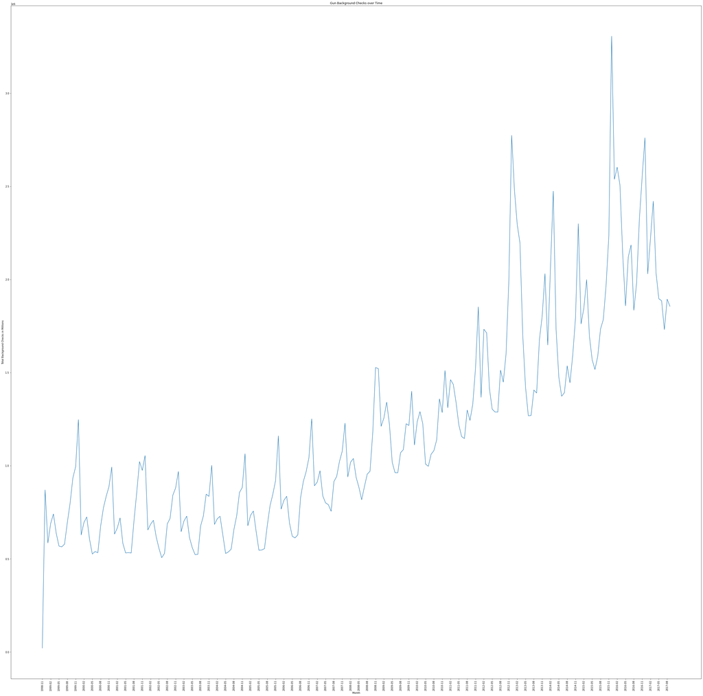

```python
# Set the figure size to be large since we have a lot of time values
plt.rcParams["figure.figsize"]=(50, 50)

# Line graph plotting function
def plot_line_graph(xvals, yvals, title ,xlabel, ylabel):
    plt.plot(xvals, yvals)
    plt.title(title)
    plt.xlabel(xlabel)
    plt.xticks(rotation='vertical')
    plt.ylabel(ylabel)
    # space out ticks
    # source: https://stackoverflow.com/questions/54783160/x-axis-tick-labels-are-too-dense-when-drawing-plots-with-matplotlib
    ax = plt.gca()
    ax.set_xticks(ax.get_xticks()[::3])
    plt.show();

# Configure parameters and call the function
title = 'Gun Background Checks over Time'
xlabel = 'Month'
ylabel = 'Total Background Checks in Millions'
xvals = sum_by_months.index
yvals = sum_by_months.totals
plot_line_graph(xvals, yvals, title ,xlabel, ylabel)
```

There are some interesting observations that we can make. First, there does appear to be a trend. I had intially wondered whether interest in firearms purchases could be related to certain events, i.e. who won a presidential election or concern over new restrictions being imposed due to mass shootings, etc.

However, looking at the plot, we can see that yearly peaks for background checks are regular and highest point seems occur around December of each year. Up until about 2010, there is a fairly regular pattern: The December peak is followed by a sharp drop and then a second smaller peak around March. After that the number of checks descends until about July, after which is increases to reach a high in December again. Starting around 2010 we still seek peaks around December and valleys in the summer, although the pattern is a little less regular.

This December peak could possibly indicate that guns are being purchased around the holidays, hence the higher number of background checks. An item that can be explored further is whether or not the background checks in December correspond to a particular type (handgun, long gun, permit) and/or are different from the types of background checks that occur at other times during the year.

Second, we can see that the number of background checks overall does appear to be increasing in general over time. Our peaks get increasingly higher and the valleys in later years aren't as low as they are in the earlier years. A point for futher exploration might be to determine how much of this increase is related to the overall increase in population in the United States during these years. Also, we might explore whether the increase in background checks is due to an increase in regulations as more states require background checks on firearm sales in more types of transactions (i.e. private sales, required permits, etc.) These last two questions are out of scope for the data that we're analyzing for this project, however we can dig deeper and explore how the three different types of background checks mentioned above (handgun, long gun, permit) compare over time.

Before we move on, because our graph is small and might be hard to read, let's print out lists of both the peaks and valleys of each complete calendar year so that we can verify that the conclusions above about peaks and valleys are correct.

```python
# Create an array of the complete years of our data
years = np.arange(1999, 2017)
years = years.astype('str')
```

```python
# Print the max per year and the month it occurred for a given column
def print_max_by_year(years, col):
    print ('Peak Month | # of Checks')
    for year in years:
        begin = year + '-01'
        end = year + '-12'
        print (sum_by_months[sum_by_months[col] == sum_by_months.loc[begin:end][col].max()].index.format(), sum_by_months.loc[begin:end][col].max())

# Print the max per year for totals
print_max_by_year(years, 'totals')
```

```
Peak Month | # of Checks
['1999-12'] 1247812
['2000-12'] 993141
['2001-12'] 1054621
['2002-12'] 969232
['2003-12'] 1002267
['2004-12'] 1064146
['2005-12'] 1160579
['2006-12'] 1251885
['2007-12'] 1228809
['2008-11'] 1527621
['2009-12'] 1400208
['2010-12'] 1511251
['2011-12'] 1852968
['2012-12'] 2774141
['2013-01'] 2481655
['2014-03'] 2474818
['2015-12'] 3306435
['2016-12'] 2761141
```

As we can see above, peak purchases were overwhelmingly in December or the surrounding months, with one exception in March 2014. Now, let's look at the valleys.

```python
# Print the min per year and the month it occurred for a given column
def print_min_by_year(years, col):
    print ('Min Month | # of Checks')
    for year in years:
        begin = year + '-01'
        end = year + '-12'
        print (sum_by_months[sum_by_months[col] == sum_by_months.loc[begin:end][col].min()].index.format(), sum_by_months.loc[begin:end][col].min())

# Print the min per year for totals
print_min_by_year(years, 'totals')
```

```
Min Month | # of Checks
['1999-06'] 564521
['2000-05'] 526074
['2001-07'] 531675
['2002-06'] 506575
['2003-06'] 523190
['2004-05'] 529241
['2005-05'] 546288
['2006-06'] 612744
['2007-07'] 755759
['2008-06'] 817800
['2009-07'] 962684
['2010-06'] 997406
['2011-07'] 1146395
['2012-07'] 1288246
['2013-06'] 1268996
['2014-06'] 1373673
['2015-06'] 1517014
['2016-08'] 1835093
```

Our valleys each year seem to occur in the summer months, particulary in June or July. We can also see that these minimums seem to be gradually getting larger over the 17 year period of our data. (We can see the same gradual increase in our maximum values above.)

Before we move on, let's take a look at the background checks for some of the specific types and see if they follow the above trends. Let's examine handgun background checks first.

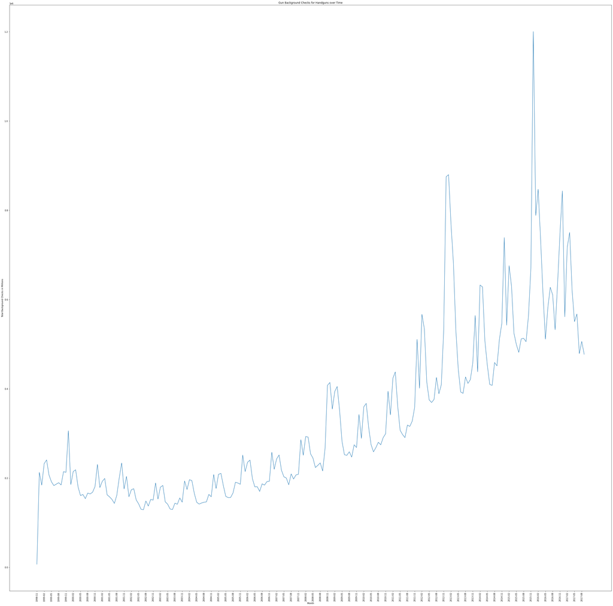

```python
# Plot a line graph of handgun background checks over time
xvals = sum_by_months.index
yvals = sum_by_months.handgun
title = 'Gun Background Checks for Handguns over Time'
xlabel = 'Month'
ylabel = 'Total Background Checks in Millions'
plot_line_graph(xvals, yvals, title ,xlabel, ylabel)
```

The chart largely follows the trends for total background checks above, although there is a small dip between 2002 and 2004. Let's look at where our peaks and valleys occur.

```python
# Print the max per year for handgun background checks
print_max_by_year(years, 'handgun')
```

```
Peak Month | # of Checks
['1999-12'] 306000
['2000-12'] 230616
['2001-10'] 233780
['2002-12'] 188998
['2003-12'] 193538
['2004-12'] 207878
['2005-12'] 251575
['2006-12'] 257810
['2007-12'] 286067
['2008-12'] 414092
['2009-03'] 405123
['2010-12'] 394557
['2011-12'] 510799
['2012-12'] 875096
['2013-01'] 879807
['2014-12'] 738893
['2015-12'] 1200444
['2016-02'] 847146
```

There's a little more variation here, but most of the peak background checks for handguns occur around December of each year.

```python
# Print the min per year for handgun background checks
print_min_by_year(years, 'handgun')
```

```
Min Month | # of Checks
['1999-06'] 183154
['2000-07'] 153871
['2001-07'] 143268
['2002-07'] 129111
['2003-07'] 129533
['2004-06'] 141695
['2005-06'] 156273
['2006-07'] 170071
['2007-07'] 185043
['2008-09'] 215963
['2009-09'] 247010
['2010-06'] 258786
['2011-07'] 290639
['2012-06'] 369318
['2013-07'] 389797
['2014-07'] 407688
['2015-06'] 481615
['2016-05'] 511223
```

Again, there's more variation than for the overall total background checks, but it generally follows the same pattern as the totals in that the valleys generally occur around the summer.

Now let's look at long guns.

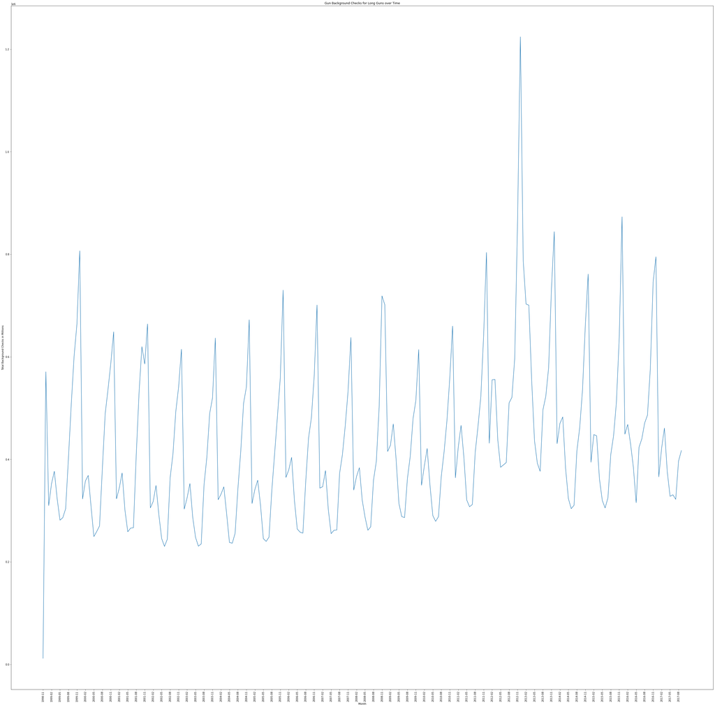

```python
#Plot a line graph of long gun background checks over time
xvals = sum_by_months.index
yvals = sum_by_months.long_gun
title = 'Gun Background Checks for Long Guns over Time'
xlabel = 'Month'
ylabel = 'Total Background Checks in Millions'
plot_line_graph(xvals, yvals, title ,xlabel, ylabel)
```

Again, we can see that the overal trend is cyclical, however the peaks are more pronounced and they seem to be occurring at around the same level over time (i.e. the peaks aren't necessarily consistently increasing over time.) Let's take a closer look at the specific values below.

```python
# Print the max per year for long gun background checks
print_max_by_year(years, 'long_gun')
```

```
Peak Month | # of Checks
['1999-12'] 806699
['2000-12'] 648698
['2001-12'] 664106
['2002-12'] 614679
['2003-12'] 636654
['2004-12'] 672195
['2005-12'] 730097
['2006-12'] 701022
['2007-12'] 637730
['2008-11'] 718820
['2009-12'] 614087
['2010-12'] 659964
['2011-12'] 803510
['2012-12'] 1224141
['2013-12'] 844083
['2014-12'] 761353
['2015-12'] 873035
['2016-12'] 795156
```

```python
# Print the min per year for long gun background checks
print_min_by_year(years, 'long_gun')
```

```
Min Month | # of Checks
['1999-05'] 281358
['2000-05'] 249332
['2001-05'] 258731
['2002-06'] 230139
['2003-06'] 230661
['2004-06'] 236392
['2005-06'] 239971
['2006-07'] 256061
['2007-05'] 255062
['2008-06'] 261754
['2009-07'] 286424
['2010-06'] 279103
['2011-06'] 307511
['2012-05'] 384539
['2013-07'] 376581
['2014-06'] 303773
['2015-06'] 305137
['2016-05'] 315485
```

We can see from above that the difference between the mins and maxes (valleys and peaks) seems to be greater for long guns than for handguns. Given that long guns are typically used for hunting, a next step could be to investigate the correlation between checks and the start and end dates of various state hunting seasons and whether there is any relation between the dates and our peaks and valleys. However, this kind of inquiry is out of the scope of the data for this project.

The last type of background check we'll look at is for permits.

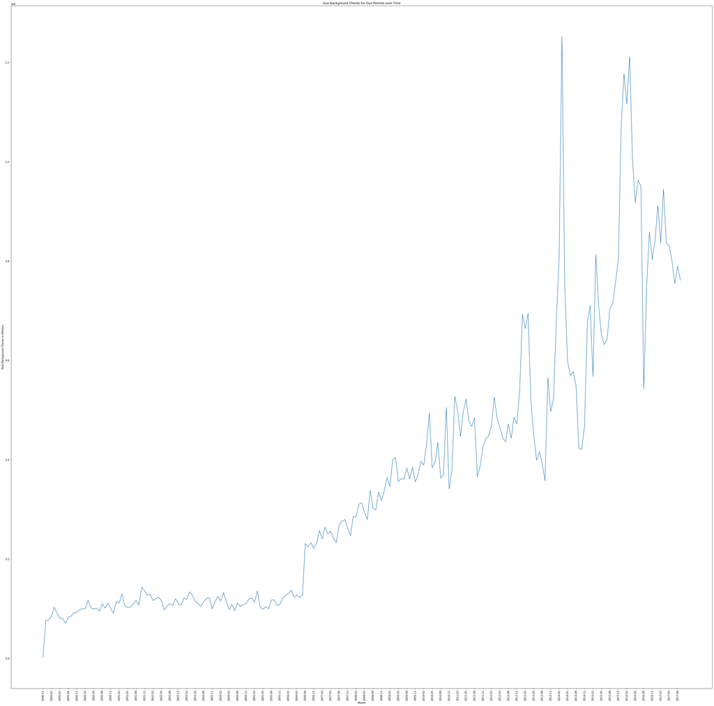

```python
# Plot a line graph of permit background checks over time
xvals = sum_by_months.index
yvals = sum_by_months.permit
title = 'Gun Background Checks for Gun Permits over Time'
xlabel = 'Month'
ylabel = 'Total Background Checks in Millions'
plot_line_graph(xvals, yvals, title ,xlabel, ylabel)
```

This looks quite different from the other graphs that we've seen so far. There don't appear to be defined cycles. Although, the number of permit background checks appear to be growing over time, there is more pronounced variation from 2012 onward. In addition there is a significant jump after August 2006. Let's look a little closer at that year.

```python
sum_by_months.loc['2006-01':'2006-12']
```

| month | permit | handgun | long_gun | multiple | admin | totals |
| --- | --- | --- | --- | --- | --- | --- |
| 2006-01 | 126476 | 214463 | 364694 | 10335 | 564 | 767220 |
| 2006-02 | 130490 | 235546 | 379526 | 11398 | 406 | 814560 |
| 2006-03 | 137252 | 240360 | 403892 | 10429 | 416 | 836459 |
| 2006-04 | 123088 | 198589 | 319930 | 9420 | 5183 | 692574 |
| 2006-05 | 127340 | 180250 | 264240 | 8276 | 3889 | 621756 |
| 2006-06 | 122483 | 180654 | 257947 | 8416 | 778 | 612744 |
| 2006-07 | 127707 | 170071 | 256061 | 8100 | 28442 | 628943 |
| 2006-08 | 231323 | 187104 | 356497 | 9432 | 486 | 829597 |
| 2006-09 | 224166 | 184214 | 441458 | 12916 | 438 | 916242 |
| 2006-10 | 233049 | 192150 | 480816 | 9839 | 440 | 968137 |
| 2006-11 | 221548 | 192827 | 561600 | 12188 | 405 | 1042638 |
| 2006-12 | 231647 | 257810 | 701022 | 19148 | 345 | 1251885 |

There was a indeed a jump in background checks for permits starting in August. The other categories don't seem to follow this pattern. Perhaps, there was a regulatory change. However, this is outside the scope of our original question, which was to investigate if there were patterns to background checks.

From the above, we can see that the permit background checks don't appear to follow the overall cyclical pattern we saw in the graph of total background checks over time. The number of background checks for handguns and long guns do fit the pattern, however. One thing to notice is that number of permit background checks increases at about the same time that our overall background checks starts to lose a little of its regularity, possibly an indication of its growing influence on the overall total number of checks.

### Research Question 2: Background Checks per capital per state

*People from which states show the most intetest in obtaining a firearm (i.e. which states have the most background checks per capita)? Which states show the least interest?*

First, just to get a general feel for our data let's look at the total number of background checks for each state.

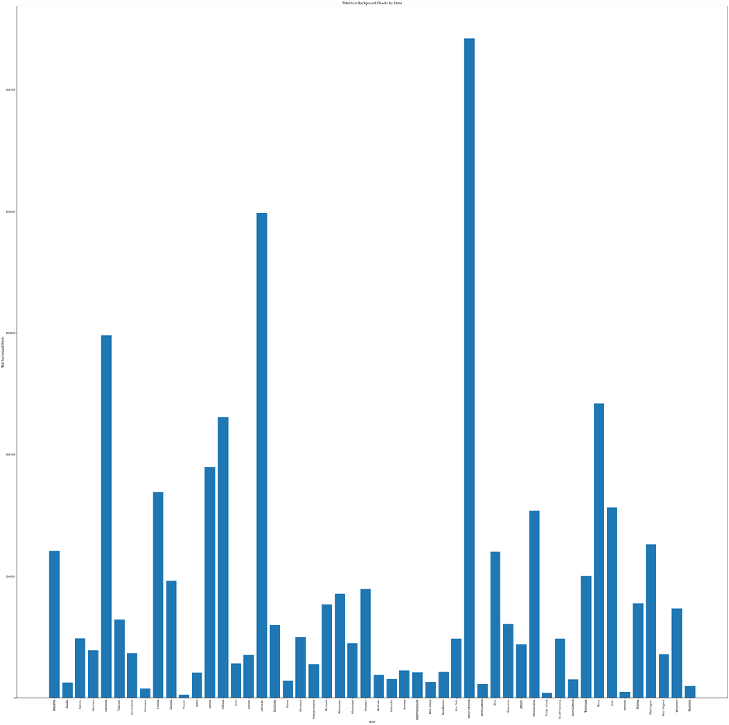

```python
# Plot a bar chart based on passed parameters
def plot_bar_chart(xvals, yvals, title, xlabel, ylabel):
    plt.bar(xvals, yvals)
    plt.xticks(rotation='vertical')
    plt.title(title)
    plt.xlabel(xlabel)
    plt.ylabel(ylabel);

# Plot a bar chart of the total number of background checks for each state
title = 'Total Gun Background Checks by State'
xlabel = 'State'
ylabel = 'Total Background Checks'
plot_bar_chart(df_guns.state, df_guns.totals, title, xlabel, ylabel)
```

Note that our total checks aren't normalized by the state's population, i.e. a state might have a large number of background checks vs. another state, but because they have a different population sizes, it is difficult to assess whether one state shows more interest in gun purchases than another. Let's fix that.

We'll need to create a new dataframe that merges total background checks by state with the census data by state. First, we'll create a dataframe with states and totals.

```python
# Create a new dataframe with totals by state
guns_by_state = pd.DataFrame(df_guns.groupby('state').totals.sum())
# Make sure that state is a column and not the index so that we can join with our census dataframe
guns_by_state.reset_index(inplace=True)
# Verify our work
guns_by_state.head()
```

|  | state | totals |
| --- | --- | --- |
| 0 | Alabama | 6706079 |
| 1 | Alaska | 1137643 |
| 2 | Arizona | 4425714 |
| 3 | Arkansas | 3752633 |
| 4 | California | 19014063 |

Now let's merge in the columns from the census dataframe.

```python
# Do an inner join on the state and verify our results
guns_by_state = guns_by_state.merge(df_census, left_on='state', right_on='state', how='inner')
guns_by_state.head()
```

|  | state | totals | est_population | high_school | university | per_cap_income | poverty | pop_per_sqmi |
| --- | --- | --- | --- | --- | --- | --- | --- | --- |
| 0 | Alabama | 6706079 | 4863300 | 0.843 | 0.235 | 24091.0 | 0.171 | 94.4 |
| 1 | Alaska | 1137643 | 741894 | 0.921 | 0.280 | 33413.0 | 0.099 | 1.2 |
| 2 | Arizona | 4425714 | 6931071 | 0.860 | 0.275 | 25848.0 | 0.164 | 56.3 |
| 3 | Arkansas | 3752633 | 2988248 | 0.848 | 0.211 | 22798.0 | 0.172 | 56.0 |
| 4 | California | 19014063 | 39250017 | 0.818 | 0.314 | 30318.0 | 0.143 | 239.1 |

To make our work easier, let's add a column for total_per_capita to our guns_by_state dataframe.

```python
# First get the total background checks per capita for each state.
total_per_cap = guns_by_state.totals/guns_by_state.est_population
```

```python
# Then add the column to our guns_by_state dataframe.
guns_by_state['total_per_cap'] = total_per_cap
guns_by_state.head()
```

|  | state | totals | est_population | high_school | university | per_cap_income | poverty | pop_per_sqmi | total_per_cap |
| --- | --- | --- | --- | --- | --- | --- | --- | --- | --- |
| 0 | Alabama | 6706079 | 4863300 | 0.843 | 0.235 | 24091.0 | 0.171 | 94.4 | 1.378915 |
| 1 | Alaska | 1137643 | 741894 | 0.921 | 0.280 | 33413.0 | 0.099 | 1.2 | 1.533431 |
| 2 | Arizona | 4425714 | 6931071 | 0.860 | 0.275 | 25848.0 | 0.164 | 56.3 | 0.638532 |
| 3 | Arkansas | 3752633 | 2988248 | 0.848 | 0.211 | 22798.0 | 0.172 | 56.0 | 1.255797 |
| 4 | California | 19014063 | 39250017 | 0.818 | 0.314 | 30318.0 | 0.143 | 239.1 | 0.484435 |

Finally, let's look at the normalized total number of background checks for each state.

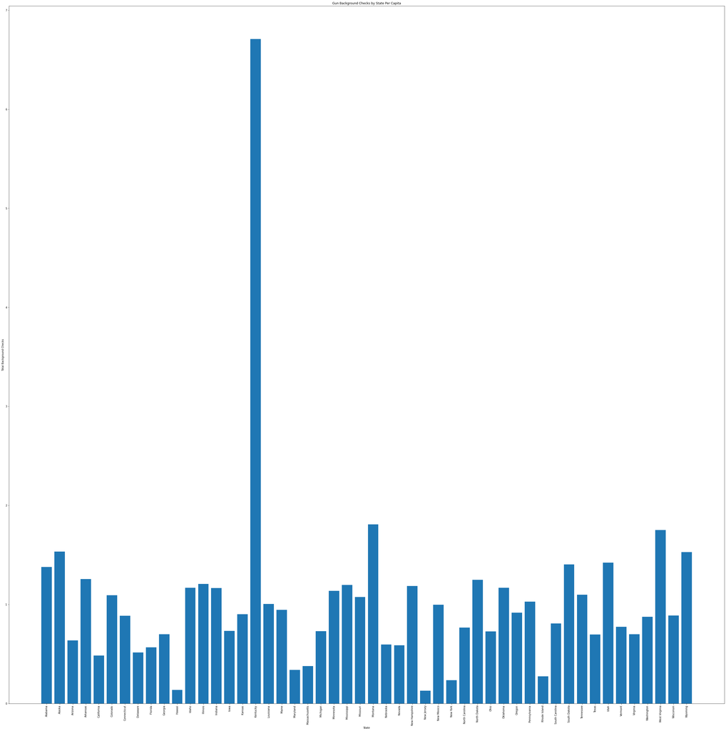

```python
# Plot a bar chart of the total number of background checks per capita for each state
title = 'Gun Background Checks by State Per Capita'
xlabel = 'State'
ylabel = 'Total Background Checks'
plot_bar_chart(guns_by_state.state, guns_by_state.total_per_cap, title, xlabel, ylabel)
```

Let's keep in mind that there are some limitations in making these comparisons. For example, not all states require a background check for the private sales of firearms, therefore these totals may not show overall interest in guns as accurately as we would like.

Which state had the fewest number of background checks? It's kind of hard to tell from the graph. So, let's use Python.

```python
# Find the state with the lowest number of per capita background checks
guns_by_state[(guns_by_state.total_per_cap) == (guns_by_state.total_per_cap).min()].state
```

```
29    New Jersey
Name: state, dtype: object
```

So, it appears that New Jersey is the state that has the fewest gun background checks per capita. From the graph we can see that Hawaii, New York and Rhode Island are also among the states with the fewest number of gun background checks.

### Research Question 3: Correlation of census characteristics

*Which demographic characteristics are most correlated with an interest in purchasing a firearm as measured by number of background checks? Specifically, are education levels, poverty rates, and population density (i.e. more or less urban or rural) correlated?*

First, let's take a look at how the checks per capita correlates to a state's poverty rate.

```python
# Configure our graph figure size.
plt.rcParams["figure.figsize"]=(8, 8)
```

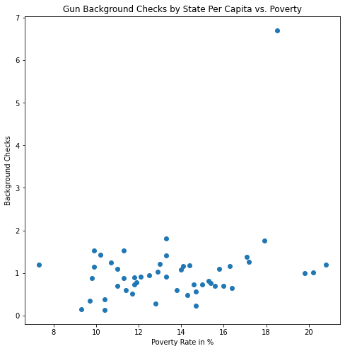

```python
# Create a scatter plot based on passed params
def plot_scatter_graph(xvals, yvals, title, xlabel, ylabel):
    plt.scatter(xvals, yvals)
    plt.title(title)
    plt.xlabel(xlabel)
    plt.ylabel(ylabel);

# Create a scatter plot of poverty rate vs. the number of background checks.
xvals = guns_by_state.poverty * 100 # Multiply poverty by 100 to plot by the percentage
yvals = guns_by_state.total_per_cap
title = 'Gun Background Checks by State Per Capita vs. Poverty'
xlabel = 'Poverty Rate in %'
ylabel = 'Background Checks'
plot_scatter_graph(xvals, yvals, title, xlabel, ylabel)
```

We can see that as the poverty rate increases, the number of background checks doesn't seem to vary much, therefore we can conclude that the two don't seem to be correlated.

Next let's explore the possible correlation between background checks and the state's percentage university graduates to explore whether education level has an impact in the interest of a given state's population in purchasing guns.

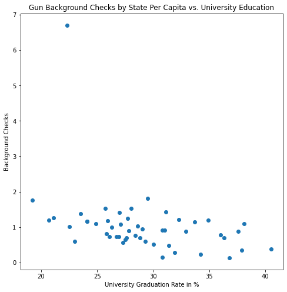

```python
# Create a scatter plot of the percentage of university graduates and the number of background checks.
xvals = guns_by_state.university * 100 # Multiply the university rate by 100 to plot by the percentage
yvals = guns_by_state.total_per_cap
title = 'Gun Background Checks by State Per Capita vs. University Education'
xlabel = 'University Graduation Rate in %'
ylabel = 'Background Checks'
plot_scatter_graph(xvals, yvals, title, xlabel, ylabel)
```

As the percentage of university graduates increases, the number of background checks does appear to decrease slightly. There is a slightly small negative correlation, meaning that the higher the university graduation rate, the lower the apparent interst in guns.

Let's look at high school graduation percentage next.

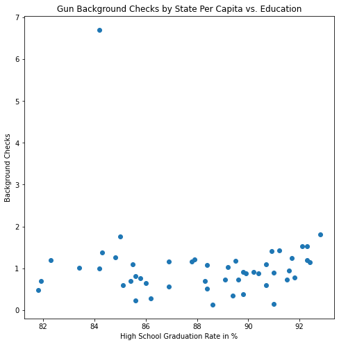

```python
# Create a scatter plot of the percentage of high school graduates and the number of background checks.
xvals = guns_by_state.high_school * 100 # Multiply the university rate by 100 to plot by the percentage
yvals = guns_by_state.total_per_cap
title = 'Gun Background Checks by State Per Capita vs. Education'
xlabel = 'High School Graduation Rate in %'
ylabel = 'Background Checks'
plot_scatter_graph(xvals, yvals, title, xlabel, ylabel)
```

As the percentage of high school graduates increases, the number of background checks doesn't seem to be affected and the two variables don't appear to be correlated.

Finally, let's look at population density. Are less dense populations (i.e. more rural) more likely to be interested in guns?

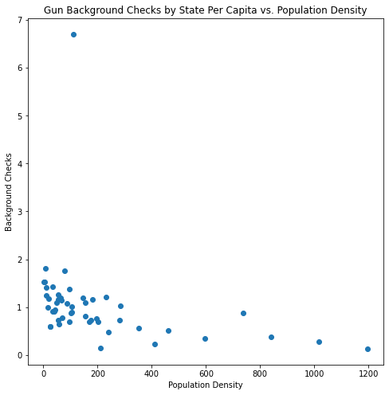

```python
# Create a scatter plot of the percentage of population density and the number of background checks.
xvals = guns_by_state.pop_per_sqmi
yvals = guns_by_state.total_per_cap
title = 'Gun Background Checks by State Per Capita vs. Population Density'
xlabel = 'Population Density'
ylabel = 'Background Checks'
plot_scatter_graph(xvals, yvals, title, xlabel, ylabel)
```

There does appear to be a slightly negative correlation between population density and background checks. It does appear that states that are less densely populated, which presumably have higher rural populations, show more interest in gun purchases.

How does this stack up to the states we identified above as showing the most interest and least interest in guns? Let's look at how those states compare to the mean university graduation rate and population density.

```python
# Mean university rate
guns_by_state.university.mean()
```

```
0.29012
```

```python
# Mean population density
guns_by_state.pop_per_sqmi.mean()
```

```
194.96200000000002
```

```python
# Grab the top 3 and bottom three states
guns_by_state[(guns_by_state.state == 'Kentucky') | (guns_by_state.state == 'Montana') | (guns_by_state.state == 'West Virginia') | (guns_by_state.state == 'New York') | (guns_by_state.state == 'Hawaii') | (guns_by_state.state == 'New Jersey')]
```

|  | state | totals | est_population | high_school | university | per_cap_income | poverty | pop_per_sqmi | total_per_cap |
| --- | --- | --- | --- | --- | --- | --- | --- | --- | --- |
| 10 | Hawaii | 197580 | 1428557 | 0.910 | 0.308 | 29822.0 | 0.093 | 211.8 | 0.138307 |
| 16 | Kentucky | 29762434 | 4436974 | 0.842 | 0.223 | 24063.0 | 0.185 | 109.9 | 6.707822 |
| 25 | Montana | 1884124 | 1042520 | 0.928 | 0.295 | 26381.0 | 0.133 | 6.8 | 1.807279 |
| 29 | New Jersey | 1145846 | 8944469 | 0.886 | 0.368 | 36582.0 | 0.104 | 1195.5 | 0.128107 |
| 31 | New York | 4643828 | 19745289 | 0.856 | 0.342 | 33236.0 | 0.147 | 411.2 | 0.235187 |
| 47 | West Virginia | 3208889 | 1831102 | 0.850 | 0.192 | 23450.0 | 0.179 | 77.1 | 1.752436 |

Out of our three ranked top states for background checks, only Montana has a university attendance rate just slightly above the mean. All three states are below the mean for population density. This is roughly what we should expect given that these variables are negatively correlated to the number of background checks

Our bottom three states (New Jersey, Hawaii and New York) all have university and population density rates higher than the mean, which corresponds to what we expect given that both are negatively correlated to the number of gun background checks.

In order to account for the influence of outliers, let's examine how these states stack up compared to the medians of these two variables.

```python
# Median university rate
guns_by_state.university.median()
```

```
0.28200000000000003
```

```python
# Median population density
guns_by_state.pop_per_sqmi.median()
```

```
98.75
```

Looking at the highest ranked states, when we look at the median university graduation rate, again only Montana has a rate just above the median. When comparing the median population density, only Kentucky is slightly above.

Looking at the lowest ranked states, all are above the median for both university graduation rate and population density.

## Conclusions

In this report we investigated interest in guns by state using the number of background checks as the key, albeit rough, indicator. First, we plotted the total number of background checks by year and saw that there appears to be a cyclical pattern. Interest, as measured by the number of background checks, peaks around December of a given year, while it falls to a low during the summer months. Also, the number of background checks has been steadily increasing over the years. We must be carefull and not necessarily jump to the conclusion that this indicates that interest in guns keeps increasing over time, as there could be other factors that are causing the number of background checks to increase, such as increasing regulations requiring checks, as well as general population growth.

Next, we turned our attention to determining which states appear to show the most and least interest in guns based upon the total number of background checks per capita. We determined that Kentucky, Montana and West Virginia had the highest number of checks per capita, while New Jersey, Hawaii and New York had the fewest number of checks per capita. Again, we must be careful in assuming that this result is an absolute indicator of interest, as not all states require certain types of background checks. For example, some states do not require background checks for private sales.

Finally, we looked at whether or not certain census statistics are correlated to the number of background checks. While poverty rate and high school education level didn't show correlation, university education and population density do appear to be slightly negatively correlated. We double-checked university and population density rates for our top and bottom states against the respective mean and median values and they generally do appear to fit the pattern.